# Session 10 - Graphical Perception

Fabian Gülzau

21 Dezember 2017

## Programm

1. Gestaltungsprinzipien
2. Cleveland & McGill (1984)
3. Cairo (2013)
4. Anwendung
5. Faktorvariablen

## Gestaltungsprinzipien

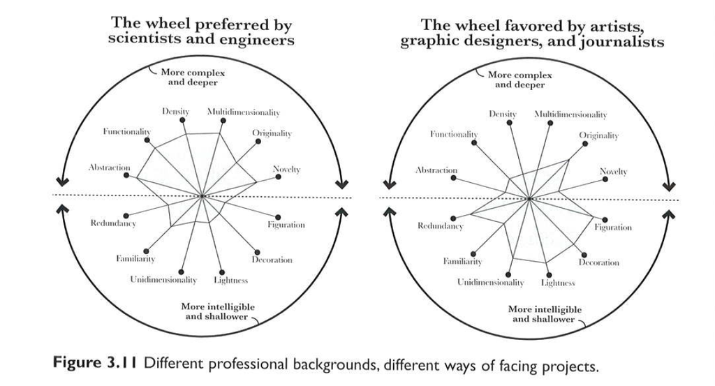

Bisher:

- Erstellung von Grafiken über die Syntax von `ggplot2`
- erste Debatte zwischen Edward Tufte und Nigel Holmes betrachtet (data-ink ration)

Nun:

- Prinzipien der Gestaltung aus Experimenten und psychologischer Forschung
- Informierte Anwendung auf eigene Grafiken

## Cleveland & McGill (1984): Elementary perceptual tasks

Entwerfen eine Theorie der “Elementary perceptual tasks” (ebd.: 532):

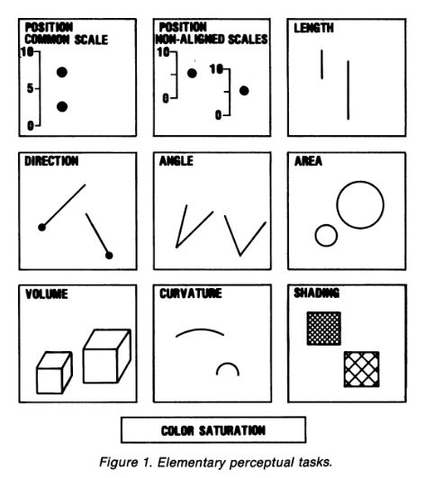

## Cleveland & McGill (1984): Experimentelle Umsetzung

Sie leiten aus ihrer Theorie ab, dass

> A graphical form that involves elementary perceptual tasks that lead to more accurate judgements than another graphical form (…) will result in better organization and increase the chances of a correct perception of patterns and behavior (ebd.: 535f.).

Und setzen dies in zwei Experimenten:

1. Position-length experiment
2. Position-angle experiment

## Cleveland & McGill (1984): Experimentelle Umsetzung

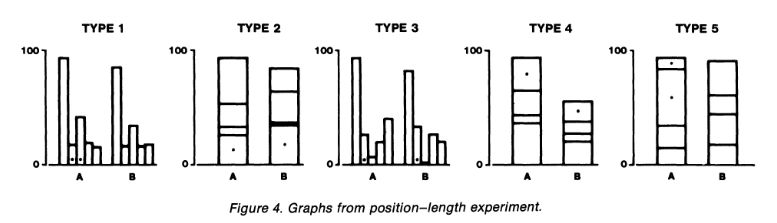

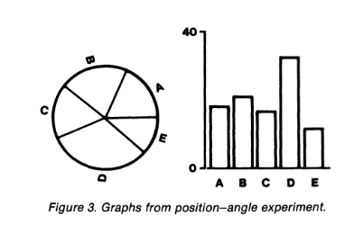

## Cleveland & McGill (1984): Ergebnisse

Die Ergebnisse bestätigen die Theorie in weiten Teilen, sodass Cleveland & McGill (1984) folgern:

> The mode of graph design that we advocate is the construction of a graphical form that uses elementary perceptual tasks as high in the hierarchy as possible (ebd.: 544).

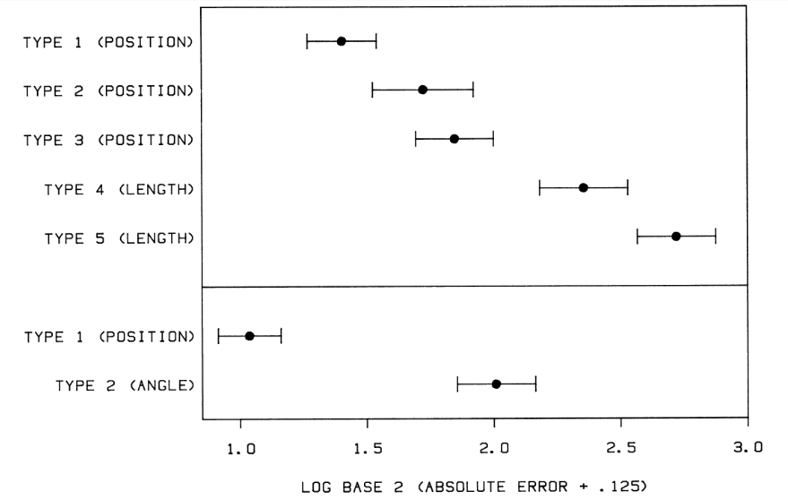

Weitere Untersuchungen konnten die Ergebnisse bestätigen ([vgl. Heer & Bostock 2010](http://idl.cs.washington.edu/papers/crowdsourcing-graphical-perception/))

## Cairo (2013): Preattentive forms

Cairo (2013) fokussiert sich in seiner Handreichung auf “mechanisms of detecting basic features, also known as *preattentive forms*” (111) und baut damit auf den Arbeiten von Cleveland & McGill (1984) auf.

Hierzu zählt er etwa die Fähigkeit “[to] discriminate between background and foreground” (ebd.):

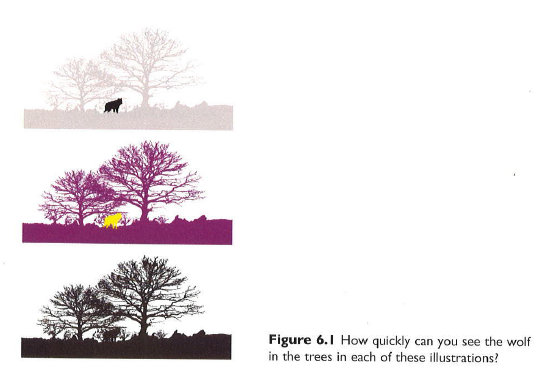

## Cairo (2013): Pattern Recognition

Basierende auf Ideen der Gestaltpsychologie identifiziert Cairo (2013) zudem weitere Prinzipien, die sich zu Grafikgestaltung nutzen lassen:

- Nähe (proximity)
- Ähnlichkeit (Similarity)
- Verbindung (Connectedness)
- Kontinuität (Continuity)
- Abgrenzung (Closure)

## Cairo (2013): Nähe

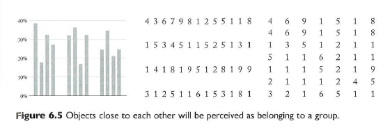

## Cairo (2013): Ähnlichkeit

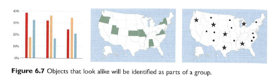

## Cairo (2013): Verbindung

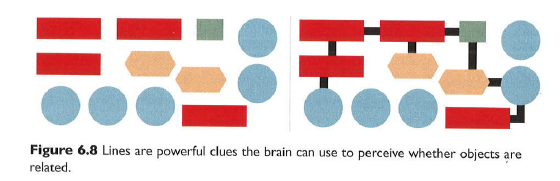

## Cairo (2013): Kontinuität

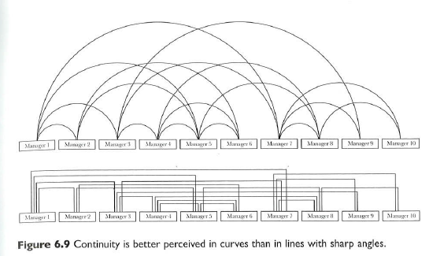

## Cairo (2013): Abgrenzung

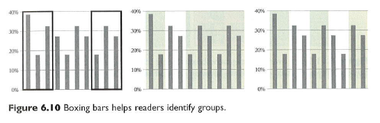

## Anwendung

- “Schlechte” Grafiken auf Moodle (oder selbst mitgebracht)
- Was ist das Ziel der Grafik (Hauptaussage)?
- Wir die Hauptaussage effektiv vermittelt?
- Wie ließe sich die Grafik nach den Prinzipien von Cairo (2013) und Cleveland & McGill (1984) verbessern?

## Faktorvariablen

Wickham und Grolemund ([2017](http://r4ds.had.co.nz/factors.html)):

> In R, factors are used to work with categorical variables, variables that have a fixed and known set of possible values. They are also useful when you want to display character vectors in a non-alphabetical order.

Siehe Dokument “Factor variables in R” auf Moodle.